# PEMODELAN IHSG DENGAN ARIMA SERTA ANALISIS OUTLIER DAN INTERVENSI

# Pemodelan ARIMA Intervensi

Keberadaan nilai ekstrem pada data harga penutupan IHSG dapat ditangani menggunakan model intervensi. Pada penelitian ini, intervensi yang digunakan adalah peristiwa pengesahan RUU TNI pada 20 Maret 2025, yang memicu perubahan struktural pada pergerakan IHSG akibat respons negatif pasar.

## Pemodelan ARIMA Pra-Intervensi

### Mengambil data pra-intervensi

Intervensi terjadi pada 20 Maret 2025, sehingga data pra intervensi adalah data pada 12 Desember 2023 hingga 19 Maret 2025

```r
> Harga.pra.intervensi = Harga[1:303]
> Harga.pra.intervensi
  [1] 7125.31 7075.34 7176.02 7190.99 7119.52 7187.85 7219.67 7209.62 7237.52
 [10] 7237.52 7245.92 7303.89 7272.80 7323.59 7279.09 7359.76 7350.62 7283.58
 [19] 7200.20 7227.30 7219.96 7241.14 7224.00 7242.79 7200.63 7252.97 7227.40
 [28] 7247.93 7256.23 7227.82 7178.04 7137.09 7157.17 7192.22 7207.94 7201.70
 [37] 7238.79 7198.62 7247.41 7235.15 7297.67 7209.74 7303.28 7335.54 7296.70
 [46] 7352.60 7349.02 7339.64 7295.10 7283.82 7285.32 7328.64 7316.11 7311.91
 [55] 7276.75 7247.46 7329.80 7373.96 7381.91 7421.21 7433.31 7328.05 7302.45
 [64] 7336.75 7331.13 7338.35 7350.15 7377.76 7365.66 7310.09 7288.81 7205.06
 [73] 7236.98 7166.84 7254.40 7286.88 7164.81 7130.84 7166.81 7087.32 7073.82
 [82] 7110.81 7174.53 7155.29 7036.08 7155.78 7234.20 7234.20 7117.42 7134.72
 [91] 7135.89 7123.61 7088.79 7099.26 7083.76 7179.83 7246.70 7317.24 7266.69
[100] 7186.04 7222.38 7176.42 7253.63 7140.23 7034.14 6970.74 7036.19 7099.31
[109] 6947.67 6974.90 6897.95 6921.55 6855.69 6850.10 6831.56 6734.83 6726.92
[118] 6819.32 6879.98 6889.17 6882.70 6905.64 6967.95 7063.58 7139.63 7125.14
[127] 7196.75 7220.89 7253.37 7250.98 7269.80 7287.04 7300.41 7327.58 7278.86
[136] 7224.29 7224.22 7321.07 7294.50 7321.98 7313.86 7262.76 7240.28 7288.17
[145] 7288.90 7241.86 7255.76 7325.98 7308.12 7059.65 7129.21 7212.13 7195.12
[154] 7257.00 7297.63 7356.64 7436.04 7409.50 7432.09 7466.83 7533.98 7554.59
[163] 7488.68 7544.30 7606.19 7597.88 7658.88 7627.60 7670.73 7694.53 7616.52
[172] 7672.90 7681.04 7721.85 7702.74 7761.39 7760.96 7798.15 7812.13 7831.78
[181] 7829.13 7905.39 7743.00 7775.73 7778.49 7740.90 7744.52 7696.92 7527.93
[190] 7642.13 7563.26 7543.83 7496.09 7504.13 7557.14 7501.29 7480.08 7520.60
[199] 7559.65 7626.95 7648.94 7735.04 7760.06 7772.60 7788.98 7787.56 7716.55
[208] 7694.66 7634.63 7606.60 7569.85 7574.02 7505.26 7479.50 7491.93 7383.87
[217] 7243.86 7287.19 7266.46 7321.99 7308.67 7214.56 7161.26 7134.28 7195.71
[226] 7180.33 7140.91 7195.56 7314.11 7245.89 7200.16 7114.27 7046.99 7196.02
[235] 7326.76 7313.31 7382.79 7437.73 7453.29 7464.75 7394.24 7324.79 7258.63
[244] 7157.73 7107.88 6977.24 6983.87 7096.44 7065.75 7036.57 7079.90 7163.21
[253] 7164.43 7080.47 7083.28 7080.35 7064.59 7088.87 7016.88 6956.67 7079.56
[262] 7107.52 7154.66 7170.74 7181.82 7257.13 7232.64 7166.06 7073.48 7109.20
[271] 7030.06 7073.46 7024.23 6875.54 6742.58 6648.14 6531.99 6645.78 6613.57
[280] 6638.46 6830.88 6873.55 6794.87 6788.04 6803.00 6749.60 6587.09 6606.18
[289] 6485.45 6270.60 6519.66 6380.40 6531.40 6617.85 6636.00 6598.21 6545.85
[298] 6665.04 6647.42 6515.63 6471.95 6223.39 6311.66
```

### Uji stasioneritas data

#### Stasioneritas terhadap ragam

```r
> Harga_plus1 = Harga.pra.intervensi - min(Harga.pra.intervensi) + 1
> BoxCox.lambda(Harga_plus1)
[1] 1.38358
```

#### Stasioneritas terhadap rata-rata

Data deret waktu yang digunakan dalam pemodelan ARIMA harus bersifat stasioner terhadap rata-rata. Untuk menguji kondisi tersebut, dapat digunakan uji Dickey-Fuller dengan hipotesis sebagai berikut.  
$H_0$ : $\phi=1$ (data tidak stasioner terhadap rata-rata) vs  
$H_1$ : $\phi<1$ (data stasioner terhadap rata-rata)  
Taraf nyata: $\alpha=0,05$  
Daerah penolakan: apabila nilai-p kurang dari $0,05$ maka $H_0$ ditolak yang artinya data stasioner terhadap rata-rata

```r
> adf.test(Harga.pra.intervensi, k=1)

    Augmented Dickey-Fuller Test

data:  Harga.pra.intervensi
Dickey-Fuller = -1.1288, Lag order = 1, p-value = 0.9167
alternative hypothesis: stationary
```

Hasil uji ADF menunjukkan nilai statistik $-1,1288$ dengan p-value $0,9167$ ($>0,05$), sehingga $H_0$ gagal ditolak. Hal ini mengindikasikan bahwa data IHSG belum stasioner dan perlu dilakukan differencing untuk menstasionerkan rata-rata.

### Proses Differencing

Berdasarkan hasil uji Dickey-Fuller, data belum stasioner terhadap rata-rata. Oleh karena itu, dilakukan proses differencing orde pertama untuk menghilangkan tren dan mencapai kondisi stasioner.

```r
> df_diffe = diff(Harga.pra.intervensi)
> adf.test(df_diffe)

    Augmented Dickey-Fuller Test

data:  df_diffe
Dickey-Fuller = -7.1821, Lag order = 6, p-value = 0.01
alternative hypothesis: stationary
```

Setelah differencing tingkat pertama ($d = 1$), uji Dickey-Fuller menghasilkan nilai statistik $-7,1821$ dengan p-value $0,01$ ($<0,05$), sehingga $H_0$ ditolak dan data dinyatakan sudah stasioner. Data kemudian dapat digunakan pada tahap identifikasi model ARIMA.

### Identifikasi Model ARIMA

Identifikasi model ARIMA dilakukan menggunakan plot ACF dan PACF. Nilai ACF dan PACF digunakan untuk menentukan orde $p$ dan $q$ pada model ARIMA. Analisis ACF dan PACF dilakukan pada data yang telah stasioner.

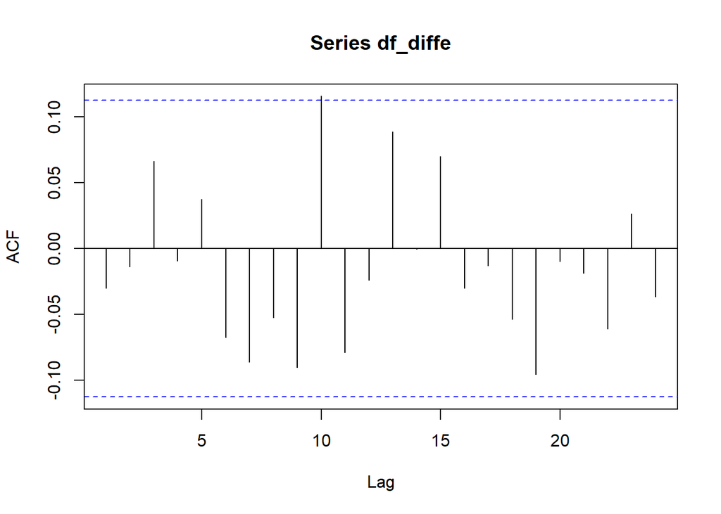

```r
> acf(df_diffe)
```

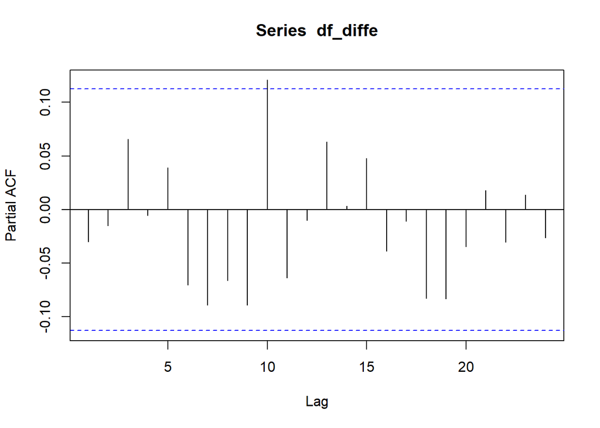

```r
> pacf(df_diffe)
```

Berdasarkan plot ACF, nilai korelasi pada lag 1 hingga 9 berada dalam batas signifikansi, sedangkan pada lag ke-10 terdapat lonjakan signifikan yang menunjukkan adanya ketergantungan terhadap error pada 10 periode sebelumnya. Hal ini mengindikasikan kandidat model MA pada lag tersebut, yaitu ARIMA(0,1,[10]).

Sementara itu, plot PACF menunjukkan pola serupa, di mana lag 1 hingga 9 tidak signifikan dan terdapat lonjakan signifikan pada lag ke-10. Kondisi ini mengindikasikan adanya komponen AR pada lag tersebut, sehingga kandidat model yang diperoleh adalah ARIMA([10],1,0).

### Pendugaan Parameter Model ARIMA

```r
> fixid = c(rep(0, 9),NA)
> arima.printer1 = arima(Harga.pra.intervensi,
+                  order = c(10, 1, 0),
+                  fixed = fixid,
+                  method = 'ML',
+                  include.mean = TRUE)
> coeftest(arima.printer1)

z test of coefficients:

     Estimate Std. Error z value Pr(>|z|)
ar10 0.125697   0.059117  2.1262  0.03348 *
---
Signif. codes:  0 '***' 0.001 '**' 0.01 '*' 0.05 '.' 0.1 ' ' 1
>
> fixid2 = c(rep(0, 9),NA)
> arima.printer2 = arima(Harga.pra.intervensi,
+                         order = c(0, 1, 10),
+                         fixed = fixid2,
+                         method = 'ML',
+                         include.mean = TRUE)
> coeftest(arima.printer2)

z test of coefficients:

     Estimate Std. Error z value Pr(>|z|)
ma10 0.135865   0.062529  2.1729  0.02979 *
---
Signif. codes:  0 '***' 0.001 '**' 0.01 '*' 0.05 '.' 0.1 ' ' 1
```

Parameter AR(10) memiliki koefisien sebesar $0,125697$ dengan p-value $0,0334$. Karena p-value < $0,05$, maka parameter tersebut signifikan secara statistik. Hal ini menunjukkan bahwa nilai IHSG saat ini dipengaruhi oleh nilai IHSG pada 10 periode sebelumnya.

Sementara itu, parameter MA(10) memiliki koefisien sebesar $0,135865$ dengan p-value $0,0297$. Karena p-value < $0,05$, maka parameter ini juga signifikan. Hal ini mengindikasikan adanya pengaruh dari komponen error pada 10 periode sebelumnya terhadap fluktuasi nilai IHSG saat ini.

Dengan demikian, kedua parameter tersebut signifikan dan model yang dibentuk dapat digunakan untuk analisis dan peramalan.

### Uji Asumsi Sisaan

Langkah selanjutnya adalah melakukan pengujian asumsi sisaan yaitu autokorelasi sisaan dan normalitas sisaan. Hipotesis untuk uji autokorelasi sisaan $H_0$ : $\rho_1=\rho_2=...=\rho_k=0$ (tidak terdapat autokorelasi pada sisaan) vs $H_1$ : minimal terdapat satu $\rho_k \neq 0$ ( terdapat autokorelasi pada sisaan) Taraf nyata: 0,05

```r
> resarima.printer = residuals(arima.printer1)
> resarima.printer2 = residuals(arima.printer2)
> Box.test(resarima.printer, lag=2, type = c('Ljung-Box'))

    Box-Ljung test

data:  resarima.printer
X-squared = 0.034089, df = 2, p-value = 0.9831
> Box.test(resarima.printer, lag=6, type = c('Ljung-Box'))

    Box-Ljung test

data:  resarima.printer
X-squared = 2.9743, df = 6, p-value = 0.8121
> Box.test(resarima.printer, lag=11, type = c('Ljung-Box'))

    Box-Ljung test

data:  resarima.printer
X-squared = 10.104, df = 11, p-value = 0.521
> Box.test(resarima.printer2, lag=2, type = c('Ljung-Box'))

    Box-Ljung test

data:  resarima.printer2
X-squared = 0.042143, df = 2, p-value = 0.9791
> Box.test(resarima.printer2, lag=6, type = c('Ljung-Box'))

    Box-Ljung test

data:  resarima.printer2
X-squared = 2.986, df = 6, p-value = 0.8106
> Box.test(resarima.printer2, lag=11, type = c('Ljung-Box'))

    Box-Ljung test

data:  resarima.printer2
X-squared = 9.9814, df = 11, p-value = 0.5321
```

Hasil uji white noise menunjukkan bahwa baik model AR maupun MA memiliki p-value yang konsisten lebih besar dari $0,05$ pada seluruh lag pengujian. Hal ini mengindikasikan bahwa kedua kandidat model telah memenuhi asumsi white noise, yang berarti tidak terdapat autokorelasi yang tersisa pada residual. Dengan demikian, dapat dinyatakan bahwa tidak terdapat autokorelasi sisaan sehingga dapat dilakukan ke tahap selanjutnya yaitu uji normalitas sisaan. Uji normalitas sisaan menggunakan uji Jarque Bera dengan hipotesis sebagai berikut. $H_0$ : $\epsilon_i\sim N(0, \sigma_e^{2})$ (sisaan menyebar normal) vs $H_1$ : $\varepsilon\not\sim\ N(0, \sigma_e^2)$ (sisaan tidak menyebar normal) Taraf nyata: $0,05$

```r
> jarque.bera.test(resarima.printer)

    Jarque Bera Test

data:  resarima.printer
X-squared = 21.252, df = 2, p-value = 2.427e-05
> jarque.bera.test(resarima.printer2)

    Jarque Bera Test

data:  resarima.printer2
X-squared = 21.062, df = 2, p-value = 2.669e-05
```

Hasil uji menunjukkan bahwa model AR memiliki p-value sebesar $2,427e-05$ dan model MA sebesar $2,669e-05$. Karena kedua nilai tersebut lebih kecil dari $0,05$, maka residual dari kedua model dinyatakan tidak berdistribusi normal.

Ketidaknormalan ini mengindikasikan adanya pengaruh pencilan (outlier) atau fluktuasi ekstrem pada data IHSG yang tidak dapat sepenuhnya ditangkap oleh model ARIMA standar. Temuan ini menjadi dasar untuk melanjutkan analisis ke tahap model intervensi guna mengakomodasi efek pencilan sehingga diperoleh model yang lebih akurat.

## Pemilihan Model Terbaik

```r
> arima.printer1$aic #AR
[1] 3400.397
> arima.printer2$aic #MA
[1] 3400.109
```

Berdasarkan nilai Akaike Information Criterion (AIC), model MA memiliki nilai AIC lebih kecil dibandingkan model AR. Oleh karena itu, model MA dipilih sebagai model terbaik karena memiliki nilai AIC minimum.

### Peramalan

Setelah diperoleh model ARIMA terbaik pada data pra-intervensi, tahap selanjutnya adalah melakukan peramalan pada periode berikutnya, yaitu mencakup data intervensi dan setelahnya. Peramalan dilakukan untuk 10 periode ke depan.

```r
> peramalan = forecast(Harga.pra.intervensi, model = arima.printer2, h=10)
> peramalan$mean
Time Series:
Start = 304
End = 313
Frequency = 1
 [1] 6323.150 6325.003 6320.593 6316.195 6332.345 6332.127 6318.235 6308.218
 [9] 6277.111 6286.138
```

Tahapan setelah melakukan peramalan yang ada pada data penelitian, langkah selanjutnya adalah menghitung sisaan dari model peramalan dengan persamaan berikut.
$$e_t = Harga_t - \hat
{Harga_t}$$

```r
> sisaan.ramalan = Harga[304:311] - peramalan$mean
> sisaan.ramalan
Time Series:
Start = 304
End = 313
Frequency = 1
 [1]   58.51988  -66.82323 -159.37277  -80.57503  140.01505  178.49277
 [7] -322.09521 -340.22804  104.55904  -27.95800
```

## Pemodelan ARIMA Intervensi

### Identifikasi Orde B,r,s

Identifikasi model intervensi digunakan untuk menentukan durasi dampak intervensi serta memilih bentuk fungsi intervensi yang sesuai. Tahap ini juga bertujuan untuk menentukan orde b, r, dan s pada model intervensi.

Proses identifikasi dilakukan dengan menganalisis respon residual pada setiap periode yang keluar dari batas signifikansi berdasarkan plot. Batas signifikansi ditentukan dari $±3(Standar Deviasi Residual)$, di mana standar deviasi tersebut diperoleh dari residual model ARIMA pada data pra-intervensi.

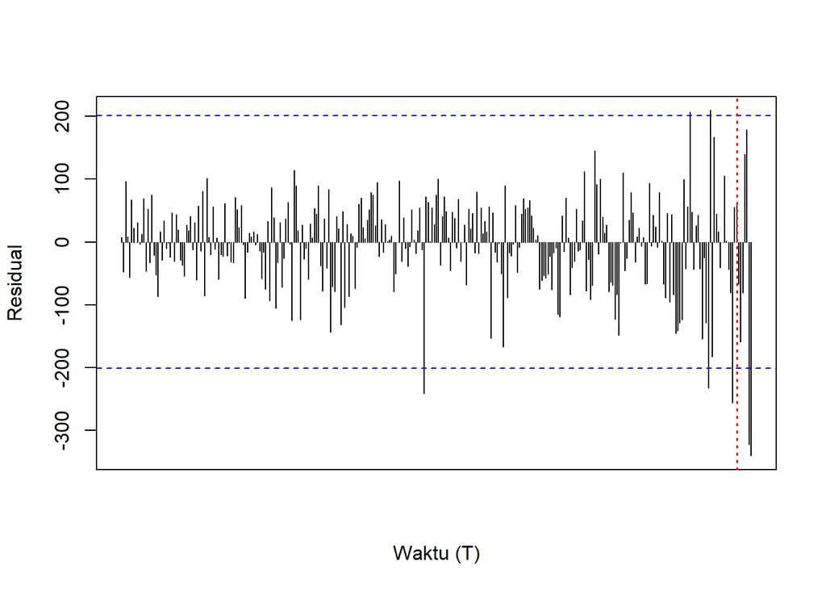

```r
> errorintv = rep(0,311)
> errorintv[1:303] = resarima1
> errorintv[304:311] = sisaan.ramalan
>
> plot(errorintv, type="h", xlab="Waktu (T)", ylab = "Residual", xaxt = "n")
> abline(h=c(-3*sd(resarima.printer2), 3*sd(resarima.printer2)), col="blue", lty=2)
> abline(v = 304, col = "red", lty = 3, lwd = 1.5)
```

### Pendugaan Parameter Model Intervensi

```r
> n=311
> AO1 = rep(0, n)
> AO2 = rep(0, n)
> TC  = rep(0, n)
>
> AO1[292:n] = 1
> AO2[311:n] = 1
> TC[151:n]  = 1
> interven = cbind(AO1, AO2, TC)
> interven = as.matrix(interven)
> model.intervensi = arimax(Harga, order = c(0, 1, 10),
+                   fixed = c(rep(0, 9),NA, NA,NA,NA),xreg = interven,
+                   method = 'ML')
> model.intervensi

Call:
arimax(x = Harga, order = c(0, 1, 10), xreg = interven, fixed = c(rep(0, 9),
    NA, NA, NA, NA), method = "ML")

Coefficients:
      ma1  ma2  ma3  ma4  ma5  ma6  ma7  ma8  ma9    ma10        AO1       AO2
        0    0    0    0    0    0    0    0    0  0.1682  -104.5954  -14.7745
s.e.    0    0    0    0    0    0    0    0    0  0.0646    73.6858   73.9039
           TC
      57.8635
s.e.  72.7083

sigma^2 estimated as 5412:  log likelihood = -1772.45,  aic = 3552.91
> coef(model.intervensi)
         ma1          ma2          ma3          ma4          ma5          ma6
   0.0000000    0.0000000    0.0000000    0.0000000    0.0000000    0.0000000
         ma7          ma8          ma9         ma10          AO1          AO2
   0.0000000    0.0000000    0.0000000    0.1682414 -104.5953654  -14.7745462
          TC
  57.8635182
```

Berdasarkan hasil analisis, model terbaik yang diperoleh adalah model intervensi dengan komponen utama MA(10). Model ini dianggap paling sesuai dalam merepresentasikan pola data IHSG, khususnya dalam kondisi adanya gangguan pasar.

Walaupun parameter intervensi berupa Additive Outlier (AO) dan Temporary Change (TC) tidak signifikan secara statistik ($|t| < 1,96$), kedua parameter tersebut tetap dipertahankan dalam model. Hal ini dilakukan karena secara substantif keduanya diperlukan untuk mengakomodasi keberadaan outlier ekstrem pada data IHSG akibat shock pasar.

Dengan mempertahankan komponen intervensi tersebut, sisaan model menjadi lebih stabil dan mendekati white noise, sehingga hasil pemodelan dan peramalan yang diperoleh menjadi lebih objektif dan reliabel.

### Pengujian Asumsi Sisaan

Model intervensi perlu melakukan uji asumsi sisaan yaitu autokorelasi sisaan dan normalitas sisaan.

```r
> resinterven = residuals(model.intervensi)
> jarque.bera.test(resinterven)

    Jarque Bera Test

data:  resinterven
X-squared = 659.23, df = 2, p-value < 2.2e-16
>
> Box.test(resinterven, lag = 2, type = "Ljung-Box")

    Box-Ljung test

data:  resinterven
X-squared = 3.9748, df = 2, p-value = 0.1371
> Box.test(resinterven, lag = 6, type = "Ljung-Box")

    Box-Ljung test

data:  resinterven
X-squared = 8.3348, df = 6, p-value = 0.2146
> Box.test(resinterven, lag = 11, type = "Ljung-Box")

    Box-Ljung test

data:  resinterven
X-squared = 14.813, df = 11, p-value = 0.1912
```

Hasil menunjukkan bahwa model intervensi telah memenuhi asumsi independensi (white noise), ditandai dengan seluruh p-value uji Ljung-Box pada lag 2, 6, dan 11 yang lebih besar dari 0,05. Hal ini berarti tidak terdapat korelasi antar sisaan sehingga model telah menangkap pola data dengan baik.

Namun, uji Jarque-Bera menunjukkan bahwa sisaan tidak berdistribusi normal (p-value < $0,05$), yang umum terjadi pada data keuangan yang bersifat volatil.

Meskipun demikian, model tetap layak digunakan untuk peramalan karena asumsi utama white noise telah terpenuhi.

## Evaluasi Akurasi Peramalan Model ARIMA Intervensi

```r
> prediksi.arima.interven = Harga-resinterven
> MAE(Harga, prediksi.arima.interven)
[1] 53.0025
> MAPE(Harga, prediksi.arima.interven)
[1] 0.007482692
> RMSE(Harga, prediksi.arima.interven)
[1] 73.44933
```

Menunjukkan hasil evaluasi akurasi model intervensi berdasarkan nilai MAE, MAPE, dan RMSE. Nilai MAPE sebesar $0,748$% menunjukkan bahwa model memiliki tingkat akurasi yang sangat tinggi (highly accurate) karena berada jauh di bawah batas $10$%.

Selain itu, nilai MAE dan RMSE yang relatif kecil dibandingkan skala data mengindikasikan bahwa kesalahan prediksi model tergolong rendah. Secara keseluruhan, model intervensi ini dapat dinilai sangat akurat dan reliabel dalam memprediksi pergerakan harga IHSG.

### Evaluasi Prediksi Grafis

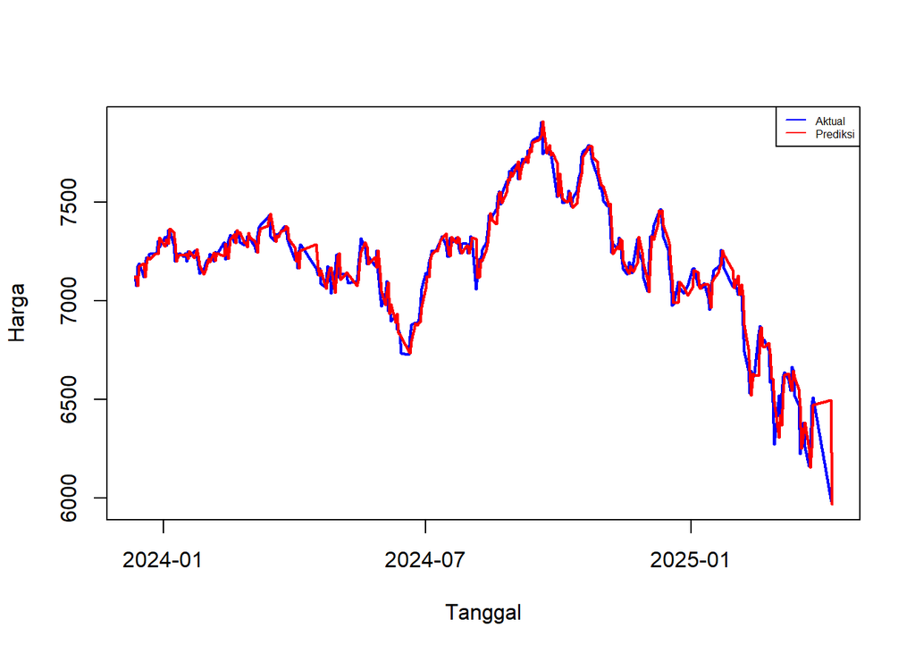

```r
> plot(Tanggal, Harga, type = "l", col = "blue", lwd = 2)
> lines(Tanggal, prediksi.arima.interven, type = "l", col = "red", lwd = 2)
> legend("topright",
+        legend = c("Aktual", "Prediksi"),
+        col = c("blue", "red"),
+        lty = 1,
+        cex = 0.5)
```

Menunjukkan bahwa model intervensi mampu mengikuti pola pergerakan IHSG dengan baik, ditandai dengan kedekatan antara nilai aktual (garis biru) dan nilai hasil pemodelan (garis merah). Hal ini mengindikasikan bahwa model mampu merepresentasikan data yang mengandung guncangan (intervensi) secara akurat.

## Plot peramalan

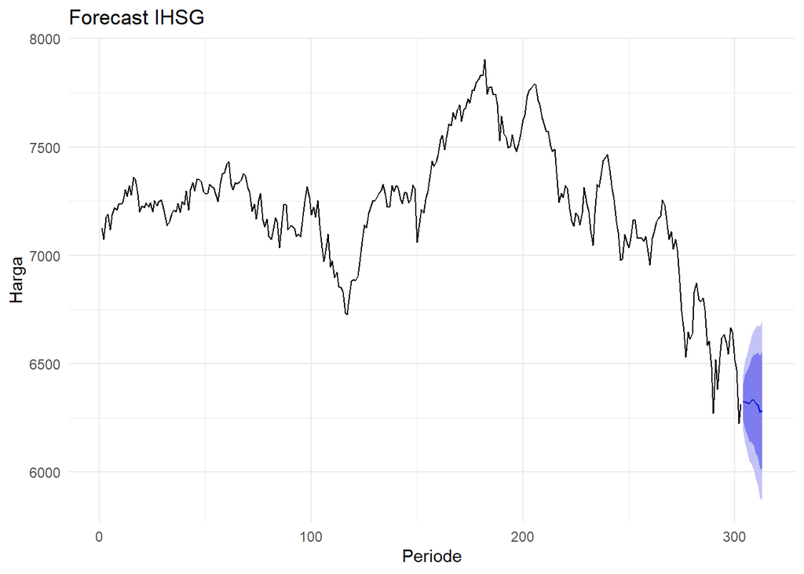

```r
> library(ggplot2)
> autoplot(peramalan) +
+   ggtitle("Forecast IHSG") +
+   xlab("Periode") +
+   ylab("Harga") +
+   theme_minimal()
```

### SARAN

1. Model yang telah diperoleh sebaiknya digunakan dengan pembaruan data secara berkala, agar hasil peramalan tetap sesuai dengan kondisi IHSG yang dinamis.
2. Keberadaan outlier dan intervensi tetap perlu diperhatikan pada analisis selanjutnya karena terbukti berpengaruh terhadap kestabilan model.
3. Model yang dihasilkan dapat dijadikan acuan awal, namun tetap terbuka untuk pengembangan lebih lanjut sesuai kebutuhan analisis.